# Как из документа MS Word сделать таблицу, с которой удобно работать

Морозова Ю.А., Баркова З.А.

11 октября 2017 г

# Введение

Иногда необходимые нам данные хранятся в файлах MS Word. В частности, на сайте российской статистической службы часто можно встретить данные в формате doc. Посмотрим, как с ними можно работать.

Для примера будем разбирать файл, находящийся по этой ссылке: http://www.gks.ru/bgd/regl/b17_02/IssWWW.exe/Stg/d010/1-05.doc

Это данные о грузообороте транспорта с 1999 по 2017 год. Они представлены в виде 9 таблиц. Но по существу эти данные включают 3 основные таблицы, а именно данные об общем грузообороте, о коммерческом грузообороте и о погрузке на железнодорожный транспорт. Каждой из основных таблиц соответствуют по 2 производные - те же показатели в процентах к соответствующему периоду предыдущего года и в процентах к предыдущему периоду. Ниже можно увидеть фрагмент данных.

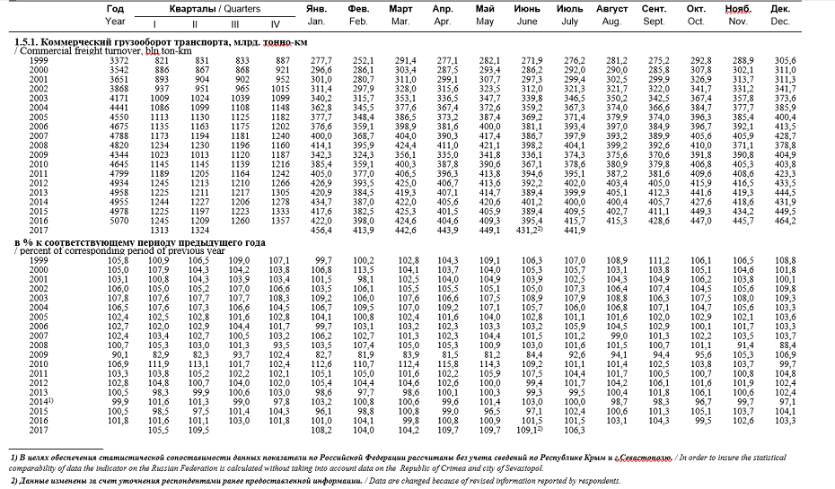

Представление данных

# Чтение файла в формате doc

Для того чтобы правильно считать таблицы из файла, нам очень важна его структура. Из файла doc трудно выделить структуру файла. Поэтому первым делом нужно открыть этот файл в MS Word и выбрать “Сохранить как” -> “Документ в строгом формате Open XML (.docx)”.

Для чтения файлов MS Word есть специальная библиотека `docxtractr`. Документацию по ней можно найти [здесь](https://cran.r-project.org/web/packages/docxtractr/docxtractr.pdf).

```r
library(tidyverse)
library(stringr)
library(lubridate)
#Для установки пакета docxtractr раскомментируйте следующую строку
#install.packages("docxtractr")
library(docxtractr)
```

Читаем файл. На выходе будет список датафреймов.

```r
doc <- read_docx("data/1-05.docx")
```

Выделим все таблицы из файла с помощью функции `docx_extract_all_tbls()`.

```r
tbl_lst <- docx_extract_all_tbls(doc)
length(tbl_lst)
```

```
## [1] 6
```

В `tbl_lst` мы получили список из 6 таблиц - каждая соответствует одному листу документа. Но в исходном документе у нас было 9 таблиц.

На примере 1-й таблицы посмотрим, как выглядят наши таблицы. Из-за сложной шапки у нас смещена строка с названием столбцов и много пропусков. Всю структуру таблиц можно посмотреть с помощью `tbl_lst`.

```r
head(tbl_lst[[1]])
```

```
##                                                                                                                                                                                                            V1
## 1
## 2
## 3 1.5. Грузооборот транспорта, включая коммерческий и некоммерческий грузооборот,         млрд.тонно-км         / Freight turnover, including commercial and noncommercial freight turnover,       bln ton-km
## 4                                                                                                                                                                                                        1999
## 5                                                                                                                                                                                                        2000
## 6                                                                                                                                                                                                        2001
##        V2                  V3       V4       V5       V6       V7     V8
## 1 ГодYear Кварталы / Quarters Янв.Jan. Фев.Feb. МартMar. Апр.Apr. МайMay
## 2                           I       II      III       IV
## 3    <NA>                <NA>     <NA>     <NA>     <NA>     <NA>   <NA>
## 4    3461               841,3    852,6    857,9    909,6    283,3  258,8
## 5    3638               907,8    889,4    895,8    945,3    302,9  293,5
## 6    3754               914,9    927,8    932,3    978,6    307,4  288,0
##         V9      V10        V11        V12      V13       V14      V15
## 1 ИюньJune ИюльJuly АвгустAug. Сент.Sept. Окт.Oct. Нояб.Nov. Дек.Dec.
## 2
## 3     <NA>     <NA>       <NA>       <NA>     <NA>      <NA>     <NA>
## 4    299,2    283,8      289,1      279,7    284,2     289,8    283,9
## 5    311,4    294,5      300,6      294,3    300,9     299,4    295,5
## 6    319,5    306,7      315,3      305,8    308,9     312,9    310,5
##     V16   V17   V18
## 1  <NA>  <NA>  <NA>
## 2
## 3  <NA>  <NA>  <NA>
## 4 301,0 295,9 312,6
## 5 316,9 309,9 318,5
## 6 336,7 322,2 319,6
```

# Приведение данных в порядок

Приведение в порядок значит, что все наблюдения должны располагаться по строкам, а переменные по столбцам.

## Выборка данных из таблиц документа MS Word

Выделим все таблицы документа и уберем у них шапки, годовые и квартальные данные.

```r
df1 <- as_tibble(tbl_lst[[1]][-(1:3),-(2:6)])
df2 <- as_tibble(tbl_lst[[2]][4:22,-(2:6)])
df3 <- as_tibble(tbl_lst[[2]][24:nrow(tbl_lst[[2]]),-(2:6)])
df4 <- as_tibble(tbl_lst[[3]][4:22,-(2:6)])
df5 <- as_tibble(tbl_lst[[3]][24:nrow(tbl_lst[[3]]),-(2:6)])
df6 <- as_tibble(tbl_lst[[4]][-(1:3),-(2:6)])
df7 <- as_tibble(tbl_lst[[5]][5:23,-(2:6)])
df8 <- as_tibble(tbl_lst[[5]][25:nrow(tbl_lst[[5]]),-(2:6)])
df9 <- as_tibble(tbl_lst[[6]][-(1:3),-(2:6)])
```

Поместим таблицы в список, чтобы обрабатывать их вместе.

```r
lst_tibbles <- list(df1,df2,df3,df4,df5,df6,df7,df8,df9)
```

## Изменение структуры таблиц

В каждой из 9 таблиц первом столбце содержится год, в остальных 12 - данные каждого показателя грузооборота за каждый месяц. Переименуем названия столбцов.

```r
for (i in seq_along(lst_tibbles)){
  colnames(lst_tibbles[[i]]) <- c("year", seq(1,12))
}
lst_tibbles[[1]]
```

```
## # A tibble: 19 x 13
##     year   `1`   `2`   `3`   `4`   `5`     `6`   `7`   `8`   `9`  `10`
##  * <chr> <chr> <chr> <chr> <chr> <chr>   <chr> <chr> <chr> <chr> <chr>
##  1  1999 283,3 258,8 299,2 283,8 289,1   279,7 284,2 289,8 283,9 301,0
##  2  2000 302,9 293,5 311,4 294,5 300,6   294,3 300,9 299,4 295,5 316,9
##  3  2001 307,4 288,0 319,5 306,7 315,3   305,8 308,9 312,9 310,5 336,7
##  4  2002 318,4 305,8 336,9 323,7 331,4   321,2 331,4 332,7 333,2 351,8
##  5  2003 347,6 323,6 361,7 344,7 355,8   349,1 356,7 361,2 354,2 378,2
##  6  2004 370,7 353,8 386,7 376,0 381,1   369,1 378,0 385,3 378,4 395,8
##  7  2005 386,0 357,7 397,1 383,1 397,1   380,3 383,5 392,0 386,0 407,5
##  8  2006 384,5 368,5 410,4 391,7 410,1   391,9 405,0 407,8 396,5 408,8
##  9  2007 408,1 378,0 415,0 400,3 426,9   397,9 409,7 405,1 401,5 417,0
## 10  2008 422,4 405,0 434,8 421,1 430,8   409,1 416,5 411,8 405,0 421,9
## 11  2009 348,9 331,6 364,5 342,8 349,6   344,2 383,2 384,8 379,9 401,5
## 12  2010 391,7 366,1 409,0 396,2 399,1   375,8 387,9 390,2 389,6 416,8
## 13  2011 411,6 384,5 415,9 405,0 423,0   404,1 405,3 397,8 392,7 420,4
## 14  2012 434,2 401,8 434,8 416,0 423,5   402,4 412,5 414,4 416,3 427,3
## 15  2013 427,3 391,9 429,3 417,1 425,1   400,2 411,2 416,7 424,2 453,8
## 16  2014 441,7 396,3 430,9 414,5 431,0   411,8 411,8 411,4 417,9 440,3
## 17  2015 424,5 390,6 433,7 409,4 414,3   398,8 419,8 413,7 422,3 460,0
## 18  2016 428,5 405,8 432,7 412,2 417,2   405,7 425,9 426,1 439,6 457,7
## 19  2017 463,7 421,5 450,5 451,4 457,4 442,01) 452,2
## # ... with 2 more variables: `11` <chr>, `12` <chr>
```

Теперь в каждой из 9 таблиц в названиях столбцов 2-13 содержатся номера месяцев. Соберем с помощью функции `gather()` номера месяцев в переменную `month`, а значения грузооборота в переменную `var`.

```r
for (i in seq_along(lst_tibbles)){ #функция gather выполняется для каждой таблицы из списка lst_tibbles
lst_tibbles[[i]] <- lst_tibbles[[i]] %>%
    gather(`1`:`12`, key = 'month', value = 'var')
}
lst_tibbles[[1]] #просмотр первой таблицы
```

```
## # A tibble: 228 x 3
##     year month   var
##    <chr> <chr> <chr>
##  1  1999     1 283,3
##  2  2000     1 302,9
##  3  2001     1 307,4
##  4  2002     1 318,4
##  5  2003     1 347,6
##  6  2004     1 370,7
##  7  2005     1 386,0
##  8  2006     1 384,5
##  9  2007     1 408,1
## 10  2008     1 422,4
## # ... with 218 more rows
```

Соединим теперь 9 таблиц в одну по ключевым столбцам `year` и `month` с помощью функции `full_join()`.

```r
turnover <- lst_tibbles[[1]]
for (i in (2:length(lst_tibbles))) {
  turnover <- turnover %>%
    full_join(lst_tibbles[[i]], by = c("year", "month"))
}
```

Переименуем названия столбцов так, чтобы в них были названия показателей.

```r
colnames(turnover) <- c("year","month","total","total_ppy","total_ppm",
                        "commercial","commercial_ppy","commercial_ppm",
                        "rail", "rail_ppy", "rail_ppm")
head(turnover)
```

```
## # A tibble: 6 x 11
##    year month total total_ppy total_ppm commercial commercial_ppy
##   <chr> <chr> <chr>     <chr>     <chr>      <chr>          <chr>
## 1  1999     1 283,3                   …      277,7           99,7
## 2  2000     1 302,9     106,9      96,9      296,6          106,8
## 3  2001     1 307,4     101,5      96,5      301,0          101,5
## 4  2002     1 318,4     103,6      99,6      311,4          103,5
## 5  2003     1 347,6     109,2      99,3      340,2          109,2
## 6  2004     1 370,7     106,7      96,9      362,8          106,7
## # ... with 4 more variables: commercial_ppm <chr>, rail <chr>,
## #   rail_ppy <chr>, rail_ppm <chr>
```

## Преобразование типов данных

Как можно заметить, все переменные имеют тип `character`. Необходимо привести их в числовой формат, однако этому мешает то, что в исходном файле возле некоторых значений стояли сноски “1)” и “2)”.

```r
filter(turnover, str_detect(total, "\\)"))
```

```
## # A tibble: 1 x 11
##    year month   total total_ppy total_ppm commercial commercial_ppy
##   <chr> <chr>   <chr>     <chr>     <chr>      <chr>          <chr>
## 1  2017     6 442,01)   108,92)      96,6    431,22)        109,12)
## # ... with 4 more variables: commercial_ppm <chr>, rail <chr>,
## #   rail_ppy <chr>, rail_ppm <chr>
```

Для того чтобы значения корректно конвертировались в числа, нужно эти сноски убрать. Воспользуемся функцией `str_replace()`, которая позволяет заменить одну строку на другую. В данном случае для поиска заменяемой подстроки используем регулярное выражение `.\\)$`, которое означает, что искомая подстрока состоит из любого символа и скобки и находится в конце. Подробнее о регулярных выражениях можно прочитать [здесь](http://r4ds.had.co.nz/strings.html).

```r
turnover <- turnover %>%
  sapply(FUN = function(x) {str_replace(x, ".\\)$", "")}) %>%
  as_tibble() #преобразование мартицы в формат tibble
```

Теперь преобразуем столбцы `year` и `month` в тип `integer` с помощью функции `parse_integer()`, а столбцы с показателями в тип `double` с помощью функции `parse_double()`. По умолчанию разделителем десятичных разрядов считается `.`. Поскольку в наших данных разделителем десятичных разрядов является `,`, укажем это в параметре `locale`.

```r
turnover <- turnover %>%
  mutate(year = parse_integer(year),
         month = parse_integer(month))

for (i in (3:ncol(turnover))){
  turnover[[i]] <- parse_double(turnover[[i]],
                                locale = locale(decimal_mark = ","))
}
head(turnover)
```

```
## # A tibble: 6 x 11
##    year month total total_ppy total_ppm commercial commercial_ppy
##   <int> <int> <dbl>     <dbl>     <dbl>      <dbl>          <dbl>
## 1  1999     1 283.3        NA        NA      277.7           99.7
## 2  2000     1 302.9     106.9      96.9      296.6          106.8
## 3  2001     1 307.4     101.5      96.5      301.0          101.5
## 4  2002     1 318.4     103.6      99.6      311.4          103.5
## 5  2003     1 347.6     109.2      99.3      340.2          109.2
## 6  2004     1 370.7     106.7      96.9      362.8          106.7
## # ... with 4 more variables: commercial_ppm <dbl>, rail <dbl>,
## #   rail_ppy <dbl>, rail_ppm <dbl>
```

```r
summary(turnover)
```

```
##       year          month           total         total_ppy
##  Min.   :1999   Min.   : 1.00   Min.   :258.8   Min.   : 81.2
##  1st Qu.:2004   1st Qu.: 3.75   1st Qu.:351.0   1st Qu.:101.0
##  Median :2009   Median : 6.50   Median :397.8   Median :103.0
##  Mean   :2009   Mean   : 6.50   Mean   :384.5   Mean   :102.7
##  3rd Qu.:2014   3rd Qu.: 9.25   3rd Qu.:417.1   3rd Qu.:105.5
##  Max.   :2017   Max.   :12.00   Max.   :474.3   Max.   :115.6
##                                 NA's   :29      NA's   :41
##    total_ppm        commercial    commercial_ppy  commercial_ppm
##  Min.   : 89.70   Min.   :252.1   Min.   : 81.2   Min.   : 89.00
##  1st Qu.: 96.65   1st Qu.:342.1   1st Qu.:100.9   1st Qu.: 96.65
##  Median : 99.95   Median :387.4   Median :103.3   Median :100.10
##  Mean   :100.33   Mean   :375.1   Mean   :102.9   Mean   :100.32
##  3rd Qu.:103.20   3rd Qu.:406.8   3rd Qu.:105.7   3rd Qu.:103.20
##  Max.   :115.60   Max.   :464.2   Max.   :115.8   Max.   :115.60
##  NA's   :30       NA's   :29      NA's   :29      NA's   :29
##       rail           rail_ppy        rail_ppm
##  Min.   : 67.40   Min.   : 66.9   Min.   : 83.50
##  1st Qu.: 93.15   1st Qu.:100.0   1st Qu.: 98.85
##  Median :102.40   Median :103.0   Median :100.80
##  Mean   : 99.64   Mean   :102.5   Mean   :100.31
##  3rd Qu.:106.35   3rd Qu.:105.3   3rd Qu.:101.95
##  Max.   :119.10   Max.   :122.9   Max.   :117.90
##  NA's   :29       NA's   :29      NA's   :29
```

## Обработка пропущенных значений

Данные столбцов преобразованы в числовой формат, однако мы можем заметить по сводке, что у нас получилось подозрительно много пропущенных значений `NA`. Кроме того, количество строк в таблице 252, хотя количество наблюдений должно быть менее 228 (19 лет по 12 месяцев). Посмотрим, в какие периоды у нас большое количество пропущенных значений.

```r
turnover %>% gather(total:rail_ppm, key = "type", value = "value") %>% #собрали значения всех переменных в один столбец, чтобы посчитать количество пропусков
  group_by(year) %>%
  summarise(na_count = sum(is.na(value))) %>%
  filter(na_count>0)
```

```
## # A tibble: 3 x 2
##    year na_count
##   <int>    <int>
## 1  1999       13
## 2  2014      216
## 3  2017       45
```

Пропущенные значения есть в 1999, 2014 и 2017 годах. В 1999 году пропуски связаны с недоступностью данных за прошлый период для расчета показателя в процентах к соответствующему периоду предыдущего года. В 2017 году пропуски соответствуют периоду, за который данные еще не появились. В 2014 году образовались дубликаты месяцев из-за того, что в исходных данных в некоторых местах в названии года присутствовали сноски со скобками, а мы их удалили уже после соединения таблиц с показателями грузооборота.

```r
filter(turnover, year==2014, !complete.cases(turnover)) %>%
  arrange(month)
```

```
## # A tibble: 36 x 11
##     year month total total_ppy total_ppm commercial commercial_ppy
##    <int> <int> <dbl>     <dbl>     <dbl>      <dbl>          <dbl>
##  1  2014     1 441.7        NA      96.8      434.7             NA
##  2  2014     1    NA     103.3        NA         NA          103.2
##  3  2014     1    NA        NA        NA         NA             NA
##  4  2014     2 396.3        NA      89.7      387.0             NA
##  5  2014     2    NA     101.1        NA         NA          100.8
##  6  2014     2    NA        NA        NA         NA             NA
##  7  2014     3 430.9        NA     108.7      422.0             NA
##  8  2014     3    NA     100.4        NA         NA          100.6
##  9  2014     3    NA        NA        NA         NA             NA
## 10  2014     4 414.5        NA      96.2      405.6             NA
## # ... with 26 more rows, and 4 more variables: commercial_ppm <dbl>,
## #   rail <dbl>, rail_ppy <dbl>, rail_ppm <dbl>
```

Чтобы исправить ситуацию группируем данные по году и месяцу и суммируем значения, исключая пропуски.

```r
turnover_fixed <- turnover %>%
  gather(total:rail_ppm, key = "type", value = "value") %>% #собираем значения переменных в один столбец
  group_by(year, month, type) %>% #группируем по году, месяцу, названию переменной
  summarise(value = ifelse(sum(!is.na(value))>0, sum(value, na.rm = TRUE), NA)) %>% #если есть непустые значения, то суммируем, иначе NA
  ungroup() %>% #убираем группировку
  spread(key = type, value = value) %>% #возвращаем названия переменных обратно в столбцы
  arrange(year, month)
```

## Расчет дополнительных столбцов данных

Добавим дату и квартал для удобства обработки данных.

```r
turnover_fixed <- mutate(turnover_fixed, date = make_date(year,month,1),
                   quarter = quarter(make_date(year,month,1))) %>%
  select(year, month, quarter, date, starts_with("total"), starts_with("com"), starts_with("rail"))
head(turnover_fixed)
```

```
## # A tibble: 6 x 13
##    year month quarter       date total total_ppm total_ppy commercial
##   <int> <int>   <int>     <date> <dbl>     <dbl>     <dbl>      <dbl>
## 1  1999     1       1 1999-01-01 283.3        NA        NA      277.7
## 2  1999     2       1 1999-02-01 258.8      91.3        NA      252.1
## 3  1999     3       1 1999-03-01 299.2     115.6        NA      291.4
## 4  1999     4       2 1999-04-01 283.8      94.8        NA      277.1
## 5  1999     5       2 1999-05-01 289.1     101.9        NA      282.1
## 6  1999     6       2 1999-06-01 279.7      96.8        NA      271.9
## # ... with 5 more variables: commercial_ppm <dbl>, commercial_ppy <dbl>,
## #   rail <dbl>, rail_ppm <dbl>, rail_ppy <dbl>
```

# Визуализация данных

Наконец данные преобразованы в удобную для анализа форму. Теперь можно приступить к анализу.

## Динамика грузооборота по годам

Построим график динамики грузооборота по годам.

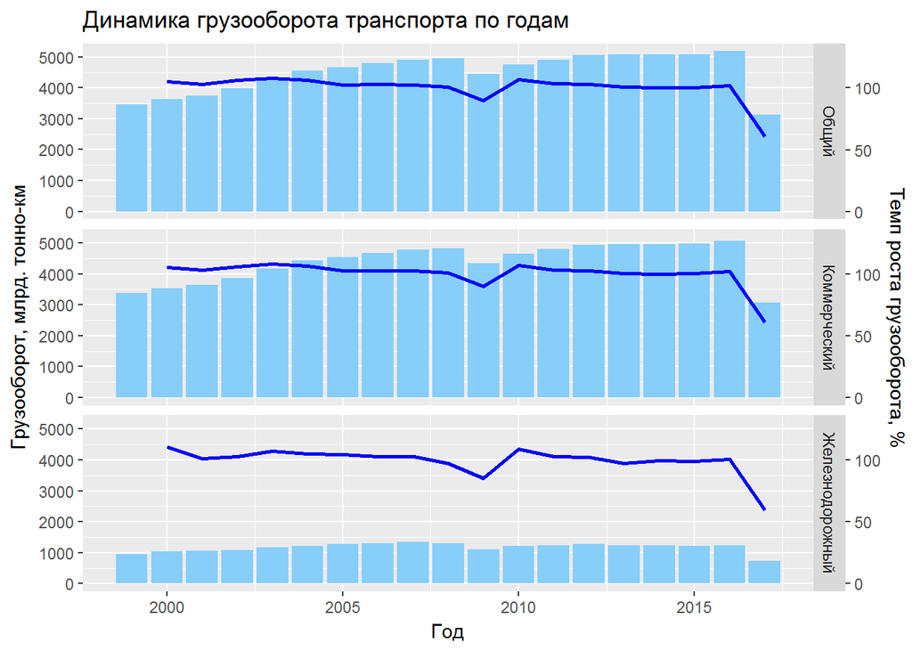

```r
by_year <- select(turnover_fixed, year, total, commercial, rail) %>%
  gather(total:rail, key = "type", value = "value") %>%
  group_by(type, year) %>%
  summarise(value = sum(value, na.rm = TRUE)) %>%
  arrange(type, year) %>%
  mutate(rate = round(value/lag(value)*100, 2)) %>%
  ungroup() %>%
  mutate(type = factor(type, levels = c("total","commercial", "rail")))

ggplot(by_year, aes(x=year)) +
  geom_bar(aes(y=value), fill = "lightskyblue", stat = "identity")+
  geom_line(aes(y=rate*40), color = "blue", size = 1)+
  facet_grid(type~., labeller = labeller(type = c(
    'total' = 'Общий',
    'commercial' = 'Коммерческий',
    'rail' = 'Железнодорожный')))+
  scale_y_continuous(sec.axis = sec_axis(~./40, name = "Темп роста грузооборота, %")) +
  labs(title = 'Динамика грузооборота транспорта по годам',
     x = 'Год',
     y = 'Грузооборот, млрд. тонно-км')
```

## Динамика грузооборота по кварталам

Построим график динамики грузооборота по кварталам.

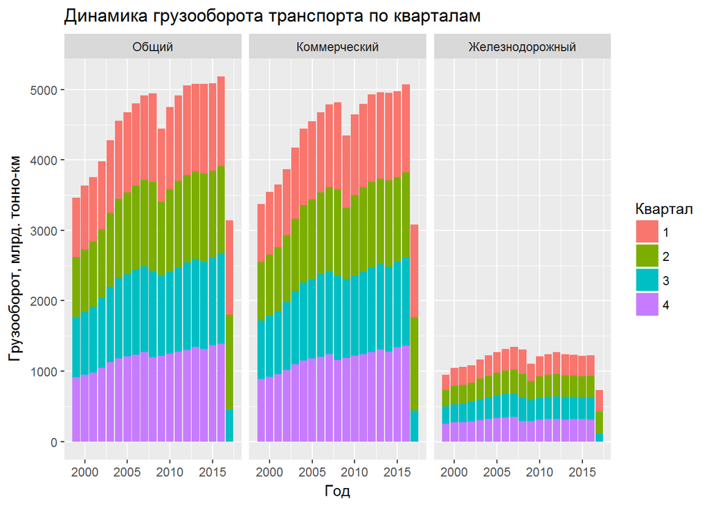

```r
by_quarter <- group_by(turnover_fixed, year, quarter) %>%
  summarise(total = sum(total, na.rm = TRUE),
            commercial = sum(commercial, na.rm = TRUE),
            rail = sum(rail, na.rm = TRUE)) %>%
  gather(total:rail, key = "type", value = "value") %>%
  mutate(type = factor(type, levels = c("total","commercial", "rail")))

ggplot(by_quarter, aes(x = year, y = value, fill = factor(quarter))) +
  geom_bar(stat = "identity") +
  facet_wrap(~type, labeller = labeller(type = c(
    'total' = 'Общий',
    'commercial' = 'Коммерческий',
    'rail' = 'Железнодорожный')))+
  labs(title = 'Динамика грузооборота транспорта по кварталам',
     x = 'Год',
     y = 'Грузооборот, млрд. тонно-км',
     fill = 'Квартал')
```

## Динамика грузооборота по месяцам

Построим график динамики грузооборота по видам транспорта по месяцам.

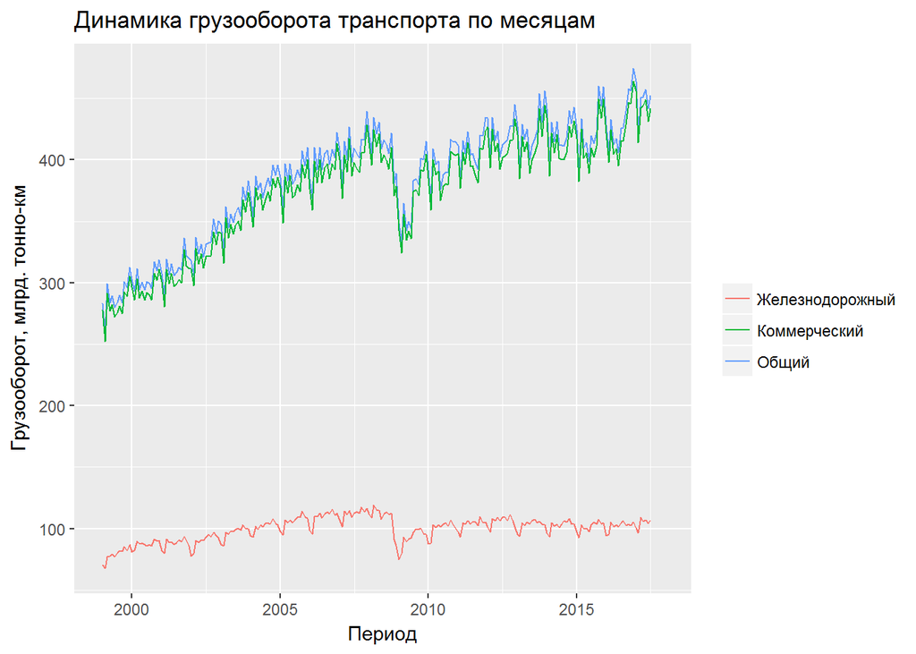

```r
ggplot(turnover_fixed, aes(x=date), size = 1) +
  geom_line(aes(y=total, color='Общий')) +
  geom_line(aes(y=commercial, color='Коммерческий')) +
  geom_line(aes(y=rail, color='Железнодорожный')) +
  labs(title = 'Динамика грузооборота транспорта по месяцам',
     x = 'Период',
     y = 'Грузооборот, млрд. тонно-км',
     color = '')
```